# **Assignment: Grammy Record of the Year Winners & Nominees**

# APPENDIX: Data Analysis

We can now commence analysing our data and answering some of the questions that we have around what (if anything) separates a Grammy nominated Record of the Year from other songs. Are there defining characteristics? The appendix follows the format below:

[1. Preparatory Actions](#preparatorya)

- [Analysis Tools and Settings](#analysistools)
- [Reading in Data](#readingit)

[2. Data Analysis - Song Characteristics](#dasongchar)

- [Valence & Energy](#valen)
- [Tempo, Danceability & Loudness](#tdloud)
- [Song Length](#songlength)

[3. Data Analysis - Success in the UK Charts](#dacharts)

[4. Data Analysis - Song Title and Artist Name Analysis](#dawords)

- [Correlations - Character & Word Length](#corrwords)
- [Language Analysis](#language)

[5. Data Analysis - Summary](#dasummary)

# **1. Preparatory Actions**

# Analysis Tools and Settings

To begin, we import various modules which will assist with analysing our dataset and plotting the results:

```python
import csv
import pandas as pd
import re
from IPython.display import display
from IPython.display import display_pretty, display_html, display_jpeg, display_png, display_json, display_latex, display_svg
from IPython.core.display import HTML
import numpy as np
from StringIO import StringIO
import requests
import sys
import urllib2
import urllib
import json
from bs4 import BeautifulSoup
from time import sleep
from datetime import datetime
import nltk
import pprint
import matplotlib.pyplot as plt
import seaborn as sns
from pylab import rcParams
%matplotlib inline
from lxml import html
import sys
import os
import sqlalchemy
from __future__ import print_function
from mysql.connector import errorcode
from seaborn import stats
```

We can also set some global parameters that will assist in formatting our outputs:

```python
pd.set_option('html', True)
pd.set_option('max_columns', 200)
pd.set_option('max_rows', 20)
rcParams['figure.figsize'] = 15, 10
rcParams['font.size'] = 16
rcParams['figure.dpi'] = 350
rcParams['lines.linewidth'] = 2
rcParams['axes.facecolor'] = 'white'
rcParams['patch.edgecolor'] = 'white'
rc={'axes.labelsize': 16, 'font.size': 16, 'legend.fontsize': 16, 'axes.titlesize': 26}
plt.rcParams.update(**rc)
sns.set_style("white")
sns.set_style("ticks")
sns.set_context({"figure.figsize": (12, 9)})
```

In addition, parameters can be set for seaborn to assist in plotting. The "newcolours" palette draws on Tableau's "Color Blind 10" and "Tableau 20" palettes, which can be viewed here: http://tableaufriction.blogspot.ro/2012/11/finally-you-can-use-tableau-data-colors.html.

Colours that make interpretation of plots by colour blind people have been chosen so as to reduce the liklihood of misinterpretation.

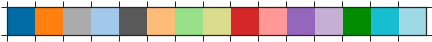

```python
newcolours = ['#006BA4', '#FF800E', '#ABABAB', '#A2C8EC', '#595959', '#FFBC79', '#98DF8A', '#DBDB8D', '#D62728', '#FF9896',
              '#9467BD', '#C5B0D5', '#008B00', '#17BECF', '#9EDAE5', '#BCBD22']
sns.palplot(sns.color_palette(newcolours, 15), 0.5)
```

# Reading In Data

We can now test to see what tables we have and also confirm the data that resides within them. Firstly, we need to connect to our SQL database so we can then start reading in data as required:

```python
from sqlalchemy import create_engine, Table, Column, Integer, String, MetaData, Date, ForeignKey, Sequence

engine = sqlalchemy.create_engine('mysql://root:password@server/grammy') # use your user details/password to connect to server
engine.execute("USE grammy")
```

```
<sqlalchemy.engine.result.ResultProxy at 0x13d145f0>
```

We can see that we have four tables residing within our SQL database:

```python
engine.table_names()
```

```
[u'artists', u'charts', u'songs', u'works']
```

If we read the data from our SQL 'works' table, we can see that this reflects the data contained within our 'grammysmain' dataset:

```python
worksa = pd.read_sql_table('works', con=engine)
worksa.head()
```

|  | echo_SONGID | year | winner | work | work_chars | work_words |
| --- | --- | --- | --- | --- | --- | --- |
| 0 | SOACACD1316771254C | 1980 | 0 | I Will Survive | 14 | 3 |
| 1 | SOACQTC1460266193F | 1961 | 0 | Are You Lonesome Tonight? | 25 | 4 |
| 2 | SOADVQH13E907C60E0 | 1994 | 0 | The River Of Dreams | 19 | 4 |
| 3 | SOAEHQL13E904FDD68 | 1997 | 0 | Because You Loved Me | 20 | 4 |
| 4 | SOAHALO131343927E9 | 1976 | 0 | Lyin' Eyes | 10 | 2 |

We can also read selected variables from our SQL database:

```python
arta = pd.read_sql("SELECT artist, echoART_ID from artists", con=engine)
arta.head()
```

|  | artist | echoART_ID |
| --- | --- | --- |
| 0 | Gloria Gaynor | ARHIET31187FB42D8D |
| 1 | Elvis Presley | ARULZ741187B9AD2EF |
| 2 | Billy Joel | ARNYFVH1187B9B6A9E |
| 3 | Celine Dion | ARFWL8S1187B9B4B44 |
| 4 | Eagles | AR16GSC1187B9A6291 |

# **2. Data Analysis - Song Characteristics**

# Valence & Energy

We are also able to ask for some more complex results using the GROUP BY function.

In the example below, we can group our nominated and winning songs by year, then average the valence for each year. 'Valence' is a psychological term; in this case it measures each song's emotional content. 1 equates to a highly positive emotion with zero indicating highly negative. [Source: https://developer.echonest.com]. EchoNest uses a combination of human response and machine learning to classify each song, so there could potentially be a few anomalies.

```python
hyu = pd.read_sql("SELECT year, AVG(valence) AS avValence FROM works w, songs s WHERE w.echo_SONGID=s.echo_SONGID GROUP BY w.year", con=engine)
hyu
```

|  | year | avValence |
| --- | --- | --- |
| 0 | 1959 | 0.598014 |
| 1 | 1960 | 0.555368 |
| 2 | 1961 | 0.425440 |
| 3 | 1962 | 0.447485 |
| 4 | 1963 | 0.489517 |
| 5 | 1964 | 0.432858 |
| 6 | 1965 | 0.548025 |
| 7 | 1966 | 0.446010 |
| 8 | 1967 | 0.588012 |
| 9 | 1968 | 0.389258 |
| ... | ... | ... |
| 47 | 2006 | 0.685731 |
| 48 | 2007 | 0.470139 |
| 49 | 2008 | 0.494272 |
| 50 | 2009 | 0.483978 |
| 51 | 2010 | 0.576586 |
| 52 | 2011 | 0.710257 |
| 53 | 2012 | 0.470387 |
| 54 | 2013 | 0.590122 |
| 55 | 2014 | 0.637039 |
| 56 | 2015 | 0.617697 |

57 rows × 2 columns

Right away we can see that in 1971 and again in 1981 the average valence levels were lower than in other years. We can plot these results to see if there are any other distinguishing features:

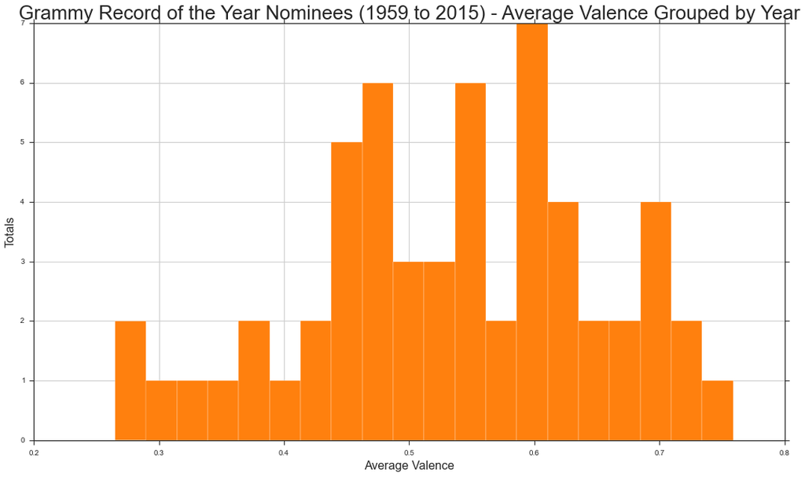

```python
rcParams['figure.figsize'] = 18, 10
hyu.hist('avValence', facecolor=newcolours[1], bins=20)
plt.title('Grammy Record of the Year Nominees (1959 to 2015) - Average Valence Grouped by Year')
sns.axlabel('Average Valence', 'Totals')
```

Putting these into bins shows two clusters in the mid to high 0.4's, then again around the mid-50's, then early 60's. If we look at this again by year and average valence, we can see a slight positive trend over time:

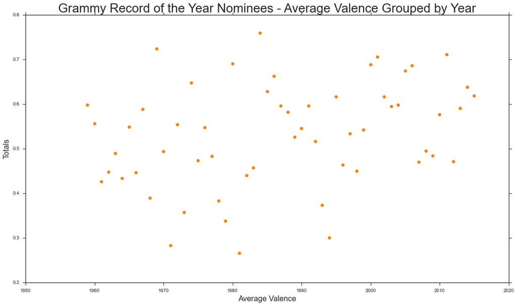

```python
plt.scatter(hyu['year'], hyu['avValence'], facecolor=newcolours[1], s=50)
rcParams['figure.figsize'] = 15, 8
plt.title('Grammy Record of the Year Nominees - Average Valence Grouped by Year')
sns.axlabel('Average Valence', 'Totals')
```

Interestingly, in the 1960's we can see that average valence was clustered around the 0.4-0.6 region. There appears to be a greater spread during the 1970's with more periods of lower average valence seen amongst the nominees. During this time the economy in the US was less successful than during the post-war boom years. The mid-1980's saw the boom during the Regan years - and the average valence has also increased. Since 2000, the average valence can be seen in clusters appearing above 0.45. In the pre-Global Financial Crisis period (2000-2006/7) we can see that average valence was higher than usual, pulling back during and post GFC to lower levels. Although this is a small sample, we could argue that nomination since 2000 could be more likely to occur if your song is happier, rather than sad.

In comparison, the EchoNest have analysed the 5,000 most popular songs every year since 1950, then provided average valence for each year. This can be seen in the scatter plot below where we overlay these averages (blue) with out existing data:

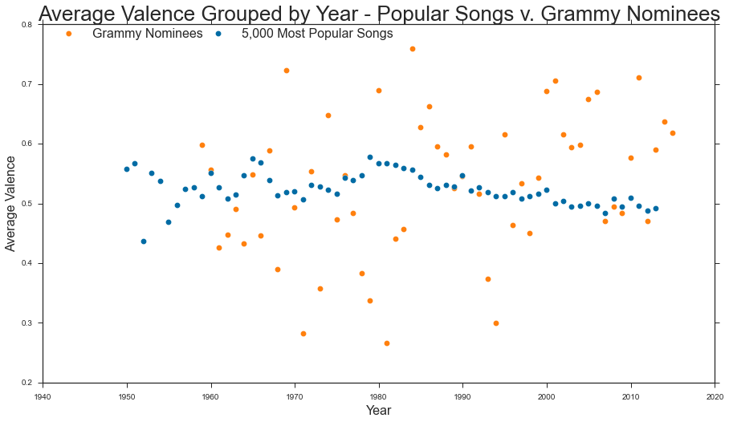

```python
uyh = pd.read_excel("EchoNestData.xlsx", "Valence")
#Source: http://blog.echonest.com/post/66097438564/plotting-musics-emotional-valence-1950-2013

x = hyu.year
z = uyh.Year

plt.scatter(x, hyu.avValence, facecolor=newcolours[1], s=50, label='Grammy Nominees')
plt.scatter(z, uyh.AvValence, facecolor=newcolours[0], s=50, label='5,000 Most Popular Songs')
plt.title('Average Valence Grouped by Year - Popular Songs v. Grammy Nominees')
sns.axlabel('Year', 'Average Valence')
plt.legend(bbox_to_anchor=(0.01, 0.94, 0.52, .102), loc=3,
           ncol=2, mode="expand", borderaxespad=0.1)
plt.show()
```

If anything, we can see a "happiness peak" in the EchoNest data from the early to mid-1980's, then a slow decline on average every year with a few peaks here and there. If this overlay with our Grammy nominees data we can see (not unexpectedly given the difference in sample sizes) that the two samples diverge. However, What is noticeable is that post-2000, when valence across the most popular songs has decreased on average, the Grammy nominated songs average valence by year has remained high (and even seen a slight increase).

Next, we can look at our nominated songs and their average energy ratings per year. Firstly, we read this data in from our SQL database and ask for the data to be grouped by year:

```python
ene = pd.read_sql("SELECT year, AVG(energy) AS avEnergy FROM works w, songs s WHERE w.echo_SONGID=s.echo_SONGID GROUP BY w.year", con=engine)
ene.info()
```

```
<class 'pandas.core.frame.DataFrame'>
Int64Index: 57 entries, 0 to 56
Data columns (total 2 columns):
year        57 non-null int64
avEnergy    57 non-null float64
dtypes: float64(1), int64(1)
memory usage: 1.3 KB
```

As a comparison, we can also read in each song's energy rating on an individual basis:

```python
een = pd.read_sql("SELECT year, energy FROM works w, songs s WHERE w.echo_SONGID=s.echo_SONGID", con=engine)
een.describe()
```

|  | year | energy |
| --- | --- | --- |
| count | 285.000000 | 285.000000 |
| mean | 1987.000000 | 0.514339 |
| std | 16.480889 | 0.225242 |
| min | 1959.000000 | 0.012796 |
| 25% | 1973.000000 | 0.339770 |
| 50% | 1987.000000 | 0.510144 |
| 75% | 2001.000000 | 0.684871 |
| max | 2015.000000 | 0.977037 |

Then compare the two in a scatter plot:

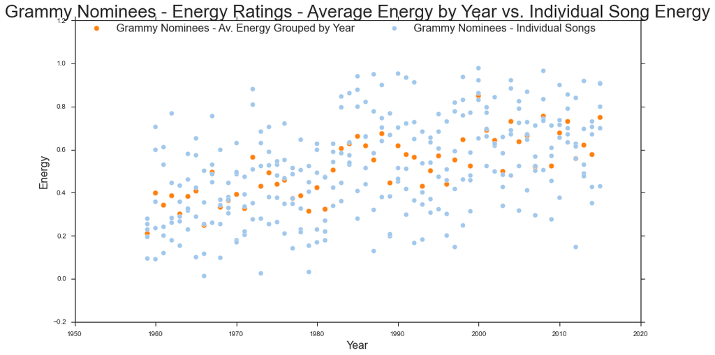

```python
x = ene.year
z = een.year

plt.scatter(x, ene.avEnergy, facecolor=newcolours[1], s=60, label='Grammy Nominees - Av. Energy Grouped by Year')
plt.scatter(z, een.energy, facecolor=newcolours[3], s=50, label='Grammy Nominees - Individual Songs')
plt.title('Grammy Nominees - Energy Ratings - Average Energy by Year vs. Individual Song Energy')
sns.axlabel('Year', 'Energy')
plt.legend(bbox_to_anchor=(0.01, 0.94, 0.92, .102), loc=3,
           ncol=2, mode="expand", borderaxespad=0.1)
plt.show()
```

We can see that the trends are very similar when comparing the average vs. individual energy ratings. These also appear to trend upwards (1 indicates high energy, 0 indicates low energy) over the time period being considered.

The full nominee data relating to energy (285 records/songs) is charted below as a histogram. It shows a reasonably normal distribution with a peak around the low 0.50 area. Contrast that with the histogram below that, which is a summary of the energy ratings in relation to over 14 million EchoNest songs. There are some differenes, with the Grammy nominees peaking in the low 0.50 region, whereas the 14 million song set has a sustained peak into the mid-0.60 region. We could argue that although our nominee songs have a small peak in the 0.2-0.3 range, they do not have the same sustained peak into the 0.60 region. Perhaps Grammy voters historically have preferred some energy but not too much? However, the plot above shows a positive rise in energy ratings over the years.

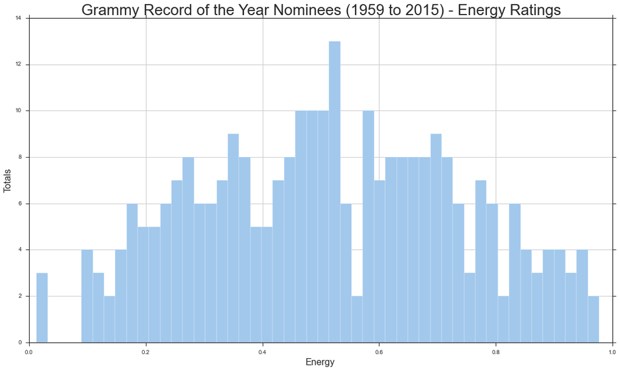

```python
rcParams['figure.figsize'] = 18, 10
een.hist('energy', facecolor=newcolours[3], bins=50)
plt.title('Grammy Record of the Year Nominees (1959 to 2015) - Energy Ratings')
sns.axlabel('Energy', 'Totals')
```

```python
HTML('<iframe src=http://dl.dropbox.com/u/18669244/runningwithdata/energy_histogram_50k.png width=800 height=600></iframe>')
#Source: http://runningwithdata.com/post/1321504427/danceability-and-energy
```

[interactive chart not shown]

We could now compare valence and energy to see if there is some correlation between the two. Firstly, we read in the data again:

```python
vaene = pd.read_sql("SELECT year, AVG(valence) AS avValence, AVG(energy) AS avEnergy FROM works w, songs s WHERE w.echo_SONGID=s.echo_SONGID GROUP BY w.year", con=engine)
vaene.describe()
```

|  | year | avValence | avEnergy |
| --- | --- | --- | --- |
| count | 57.000000 | 57.000000 | 57.000000 |
| mean | 1987.000000 | 0.532366 | 0.514339 |
| std | 16.598193 | 0.116068 | 0.142088 |
| min | 1959.000000 | 0.264976 | 0.210259 |
| 25% | 1973.000000 | 0.456521 | 0.397307 |
| 50% | 1987.000000 | 0.545371 | 0.520522 |
| 75% | 2001.000000 | 0.615460 | 0.621755 |
| max | 2015.000000 | 0.758904 | 0.848625 |

```python
eneva = pd.read_sql("SELECT year, valence, energy FROM works w, songs s WHERE w.echo_SONGID=s.echo_SONGID", con=engine)
eneva.describe()
```

|  | year | valence | energy |
| --- | --- | --- | --- |
| count | 285.000000 | 285.000000 | 285.000000 |
| mean | 1987.000000 | 0.532366 | 0.514339 |
| std | 16.480889 | 0.247812 | 0.225242 |
| min | 1959.000000 | 0.037615 | 0.012796 |
| 25% | 1973.000000 | 0.349272 | 0.339770 |
| 50% | 1987.000000 | 0.539422 | 0.510144 |
| 75% | 2001.000000 | 0.729563 | 0.684871 |
| max | 2015.000000 | 0.975778 | 0.977037 |

Paul Lamere, Director of Developer Platform at EchoNest, explained the relationship between energy (arousal) and valence. High energy / high valence equates to positive emotions - astonishment, delight, happiness. Low energy but high valence also equate to positive emotion, but on a more sedate scale (pleased, content, satisfied). On the flipside, high energy but low valence equate to negatively aroused emotions such as alarm, anger and annoyance. Low valence and low energy equate to misery, boredom and tiredness. These are showsn below in Russell's Valence-Arousal space:

```python
HTML('<iframe src=http://musicmachinery.files.wordpress.com/2010/08/ismir2010-45-pdf-page-3-of-12.png width=500 height=450></iframe>')
#Source: Paul Lamere, Director of Developer Platform at The EchoNest - https://github.com/doubledherin/Audio_Snowflake
```

[interactive chart not shown]

If we visualise both datasets (average valence and energy grouped by year, plus individual song energy and valence) in a scatter plot the we can see where on the Valence-Arousal space our songs tend to sit:

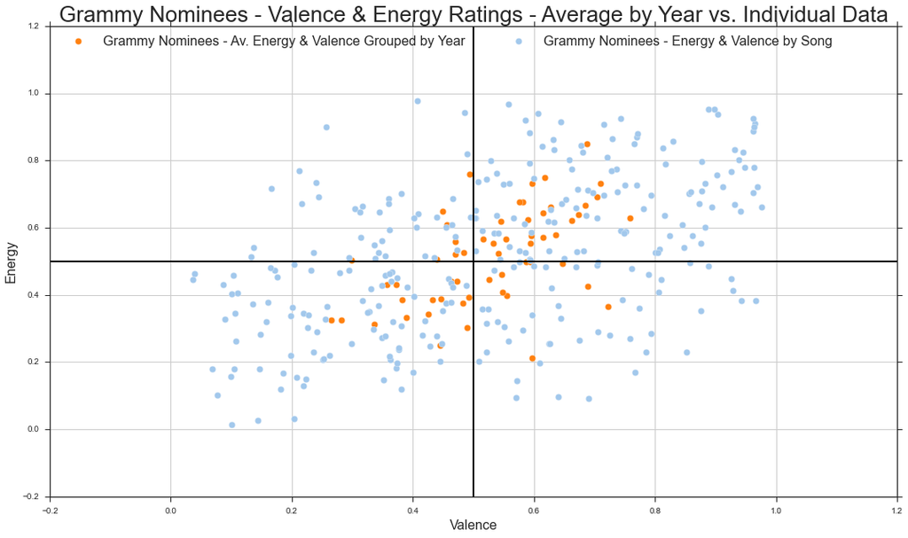

```python
x = vaene.avValence
z = eneva.valence

plt.scatter(x, vaene.avEnergy, facecolor=newcolours[1], s=60, label='Grammy Nominees - Av. Energy & Valence Grouped by Year')
plt.scatter(z, eneva.energy, facecolor=newcolours[3], s=60, label='Grammy Nominees - Energy & Valence by Song')
plt.title('Grammy Nominees - Valence & Energy Ratings - Average by Year vs. Individual Data')
sns.axlabel('Valence', 'Energy')
plt.grid(which='major', axis='both')
plt.axhline(y=0.5, color='black')
plt.axvline(x=0.5, color='black')
plt.legend(bbox_to_anchor=(0.01, 0.94, 0.92, .102), loc=3,
           ncol=2, mode="expand", borderaxespad=0.1)
plt.show()
```

Interestingly, it appears that to be nominated it is advantageous to be in the upper right or lower left quadrants. To a lesser extent, the lower right quadrant placement (a sedate kind of happy) could also be a good place to be. There are fewer songs in the upper left quadrant (an agressive kind of unhappy); those that are are clustered towards the central point.

From this, we could potentially infer that you are less likely to win if you are in the "aggressive kind of unhappy" quadrant. We can compare winners to nominees on an individual basis below and see:

```python
evwin = pd.read_sql("SELECT year, valence, energy FROM works w, songs s WHERE w.echo_SONGID=s.echo_SONGID AND w.winner=1", con=engine)
ewnom = pd.read_sql("SELECT year, valence, energy FROM works w, songs s WHERE w.echo_SONGID=s.echo_SONGID AND w.winner=0", con=engine)
```

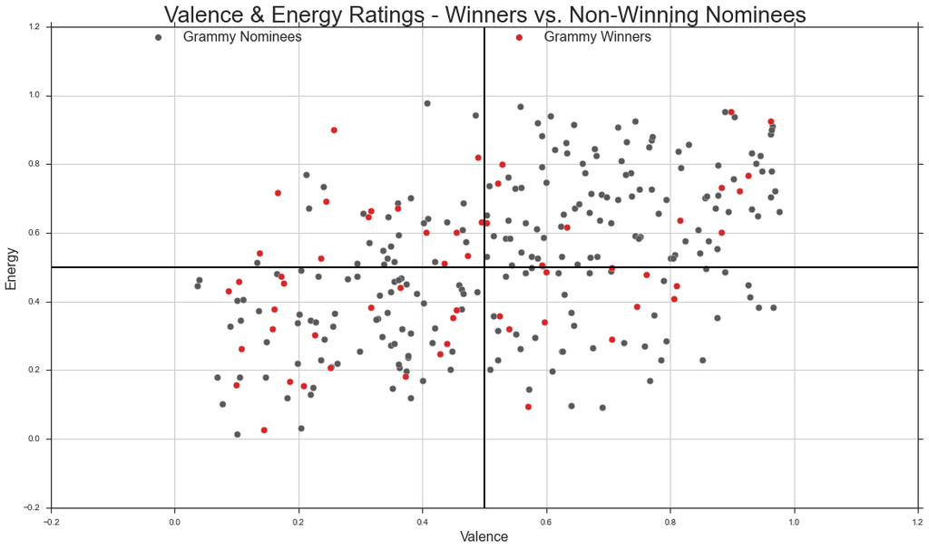

```python
z = ewnom.valence
m = evwin.valence

plt.scatter(z, ewnom.energy, facecolor=newcolours[4], s=60, label='Grammy Nominees')
plt.scatter(m, evwin.energy, facecolor=newcolours[8], s=60, label='Grammy Winners')
plt.title('Valence & Energy Ratings - Winners vs. Non-Winning Nominees')
sns.axlabel('Valence', 'Energy')
plt.grid(which='major', axis='both')
plt.axhline(y=0.5, color='black')
plt.axvline(x=0.5, color='black')
plt.legend(bbox_to_anchor=(0.10, 0.95, 0.6, .102), loc=3,
           ncol=2, mode="expand", borderaxespad=0.1)
plt.show()
```

The top left quadrant has 39 songs in total - 14 of which were winners. The bottom left quadrant has 87 songs in total, 20 of which were winners. Contrast this with the 110 songs in the high energy/high valence quadrant; only 12 of these won.

The winners in the low valence/low energy quadrant are more likely to have a valence rating between 0 and 0.25. Likewise, the upper right quadrant winners are visible at the margins as opposed to the centre of the quadrant where the losing nominees are.

The two most heavily populated quadrants - upper right and lower left - have a total of 197 of the 285 songs.

This tells us that although nominees are more likely to be high energy/high valence or low energy/low valence, it does not guarantee a win. In fact, songs deemed "sadder" have won more often than happier songs. There could be a number of reasons for this. An aggressively sad song, surrounded by happy peppy songs, may stand out more in the minds of voters. Likewise, happy peppy songs surrounded by similar songs may split the vote, leaving the sad song to win.

Although happier songs have the slight edge in nominations (159/285), sadder songs appear to have the edge when it comes to winning (34/57).

We can now group songs by decade and see if there are any trends. Firstly, we add a new column to our dataframe and apply a function that determines which decade a song fits into (note, as we only have one song from the 1950's this has been grouped in with the 1960's):

```python
evwin.insert(1, 'decade', '')
def func001(dec1):
    if dec1['year'] <= 1969:
        return 1960
    elif 1969 < dec1.year < 1980:
        return 1970
    elif 1979 < dec1.year < 1990:
        return 1980
    elif 1989 < dec1.year < 2000:
        return 1990
    elif 1999 < dec1.year < 2010:
        return 2000
    else:
        return 2010

evwin['decade'] = evwin.apply(func001, axis=1)
evwin
```

|  | year | decade | valence | energy |
| --- | --- | --- | --- | --- |
| 0 | 2004 | 2000 | 0.244728 | 0.689801 |
| 1 | 1986 | 1980 | 0.363947 | 0.439666 |
| 2 | 1971 | 1970 | 0.252334 | 0.204733 |
| 3 | 1976 | 1970 | 0.911839 | 0.720348 |
| 4 | 1994 | 1990 | 0.136682 | 0.540036 |
| 5 | 1984 | 1980 | 0.816265 | 0.634212 |
| 6 | 1997 | 1990 | 0.489931 | 0.818346 |
| 7 | 1977 | 1970 | 0.455215 | 0.372852 |
| 8 | 1972 | 1970 | 0.449321 | 0.351777 |
| 9 | 1978 | 1970 | 0.593210 | 0.504690 |
| ... | ... | ... | ... | ... |
| 47 | 2001 | 2000 | 0.317310 | 0.662635 |
| 48 | 1999 | 1990 | 0.103665 | 0.457188 |
| 49 | 1966 | 1960 | 0.525323 | 0.355953 |
| 50 | 1965 | 1960 | 0.705682 | 0.289750 |
| 51 | 1991 | 1990 | 0.435969 | 0.510144 |
| 52 | 1979 | 1970 | 0.100294 | 0.154598 |
| 53 | 2009 | 2000 | 0.439781 | 0.274985 |
| 54 | 2006 | 2000 | 0.313596 | 0.644892 |
| 55 | 1963 | 1960 | 0.208170 | 0.152279 |
| 56 | 1988 | 1980 | 0.257518 | 0.898655 |

57 rows × 4 columns

We can now plot the results into separate charts:

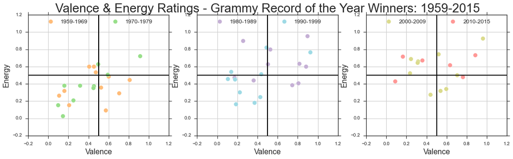

```python
evwina = evwin[(evwin['decade'] == 1960)]
evwinb = evwin[(evwin['decade'] == 1970)]
evwinc = evwin[(evwin['decade'] == 1980)]
evwind = evwin[(evwin['decade'] == 1990)]
evwine = evwin[(evwin['decade'] == 2000)]
evwinf = evwin[(evwin['decade'] == 2010)]

n = evwina.valence
o = evwinb.valence
p = evwinc.valence
q = evwind.valence
r = evwine.valence
s = evwinf.valence

plt.subplot(2, 3, 1)
plt.scatter(n, evwina.energy, facecolor=newcolours[5], s=80, label='1959-1969')
plt.scatter(o, evwinb.energy, facecolor=newcolours[6], s=80, label='1970-1979')
sns.axlabel('Valence', 'Energy')
plt.grid(which='major', axis='both')
v=(-0.2, 1.2, -0.2, 1.2)
plt.axis(v)
plt.axhline(y=0.5, color='black')
plt.axvline(x=0.5, color='black')
plt.legend(bbox_to_anchor=(0.1, 0.90, 0.8, .5), loc=3,
           ncol=2, mode="expand", borderaxespad=0.1, fontsize=12)

plt.subplot(2, 3, 2)
plt.scatter(p, evwinc.energy, facecolor=newcolours[11], s=80, label='1980-1989')
plt.scatter(q, evwind.energy, facecolor=newcolours[14], s=80, label='1990-1999')
sns.axlabel('Valence', 'Energy')
plt.title('Valence & Energy Ratings - Grammy Record of the Year Winners: 1959-2015')
plt.grid(which='major', axis='both')
v=(-0.2, 1.2, -0.2, 1.2)
plt.axis(v)
plt.axhline(y=0.5, color='black')
plt.axvline(x=0.5, color='black')
plt.legend(bbox_to_anchor=(0.1, 0.90, 0.8, .5), loc=3,
           ncol=2, mode="expand", borderaxespad=0.1, fontsize=12)

plt.subplot(2, 3, 3)
plt.scatter(r, evwine.energy, facecolor=newcolours[7], s=80, label='2000-2009')
plt.scatter(s, evwinf.energy, facecolor=newcolours[9], s=80, label='2010-2015')
sns.axlabel('Valence', 'Energy')
plt.grid(which='major', axis='both')
v=(-0.2, 1.2, -0.2, 1.2)
plt.axis(v)
plt.axhline(y=0.5, color='black')
plt.axvline(x=0.5, color='black')
plt.legend(bbox_to_anchor=(0.1, 0.90, 0.8, .5), loc=3,
           ncol=2, mode="expand", borderaxespad=0.1, fontsize=12)
plt.show()
```

The 1980's (purple) saw a rise in winning song energy levels (and a buoyant American economy in the mid-to-late decade), with a cluster appearing in the high energy/high valence quadrant. The exception was Paul Simon's "Graceland", with it's high energy/low valence - a reflection of its upbeat sounding music but lyrics dealing with Simon's thoughts on his marriage break up. The 1990's saw a shift back to the low valence/low energy type of song, with the exception of Sheryl Crow's "All I Wanna Do" in 1995 (valence = 0.92) and Eric Clapton's 1997 hit "Change The World" (0.82 energy).

The 2000's winning songs were centrally clustered, with only one outlier (Santana's "Smooth", energy = 0.92). The 2010-14 songs showed a year on year increase in valence until Sam Smith's 2015 winning song "Stay With Me" (lower right quadrant).

What does this tell us? The trend since the 1980's appears to be away from songs with low energy and low happiness levels. There was a shift back in the 1990's when slower songs like "I Will Always Love You" and "Tears in Heaven" dominated, but the 21st Century saw a shift away. Valence levels had been increasing post 2010 until Sam Smith's win in 2015. Does Smith's win show a new trend emerging or just an outlier?

The table below shows each decade with average valence and energy levels. On average, the 21st Century winners have similar valence and energy readings:

```python
evwinq = evwin.groupby(['decade'])[['valence', 'energy']]
evwinq.mean()
```

| decade | valence | energy |
| --- | --- | --- |
| 1960 | 0.456632 | 0.375461 |
| 1970 | 0.388041 | 0.372285 |
| 1980 | 0.597728 | 0.620897 |
| 1990 | 0.348275 | 0.443859 |
| 2000 | 0.487968 | 0.561745 |
| 2010 | 0.482471 | 0.605770 |

# Tempo, Danceability & Loudness

Other song measures available via EchoNest include tempo, danceability and loudness. We can query our SQL database and ask for the information regarding each of these variables, grouping them by year and calculating the average. The high-level summary statistics are described below:

```python
tdlavg = pd.read_sql("SELECT year, AVG(tempo) AS avTempo, AVG(danceability) AS avDanceability, AVG(loudness) as avLoudness FROM works w, songs s WHERE w.echo_SONGID=s.echo_SONGID GROUP BY w.year", con=engine)
tdlavg.describe()
```

|  | year | avTempo | avDanceability | avLoudness |
| --- | --- | --- | --- | --- |
| count | 57.000000 | 57.000000 | 57.000000 | 57.000000 |
| mean | 1987.000000 | 116.264793 | 0.558424 | -11.043698 |
| std | 16.598193 | 11.621246 | 0.087945 | 2.345049 |
| min | 1959.000000 | 82.078000 | 0.367425 | -17.942200 |
| 25% | 1973.000000 | 107.982802 | 0.500414 | -12.486800 |
| 50% | 1987.000000 | 118.638400 | 0.563911 | -11.315600 |
| 75% | 2001.000000 | 122.220000 | 0.628144 | -9.204000 |
| max | 2015.000000 | 144.342802 | 0.713731 | -5.297000 |

If we look at tempo we can see a peak/cluster around 120 beats per minute, then with a smaller cluster to the left at around 105-110 beats per minute:

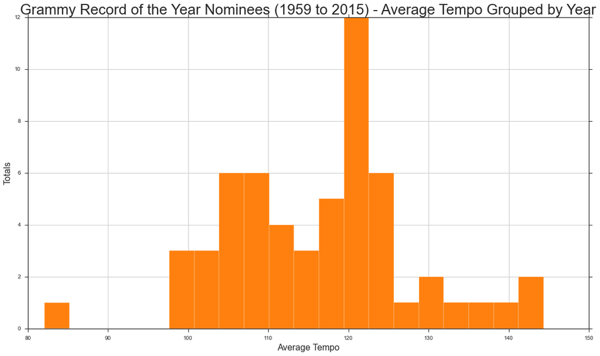

```python
rcParams['figure.figsize'] = 18, 10
tdlavg.hist('avTempo', facecolor=newcolours[1], bins=20)
plt.title('Grammy Record of the Year Nominees (1959 to 2015) - Average Tempo Grouped by Year')
sns.axlabel('Average Tempo', 'Totals')
```

We can also compare our nominees and then the average grouped by year with EchoNest averages analysis of the most popular (5,000) songs per year between 1950 and 2013.

Firstly, we read in our EchoNest data and call on our SQL database to obtain individual data regarding all of our songs:

```python
mep = pd.read_excel("EchoNestData.xlsx", "Tempo")
#Source: http://blog.echonest.com/post/61686021710/people-liked-their-music-fastest-in-the-80s
tempyr = pd.read_sql("SELECT year, tempo, danceability, loudness FROM works w, songs s WHERE w.echo_SONGID=s.echo_SONGID", con=engine)
```

We can then plot these three factors against each other in an attempt to derive some further insight:

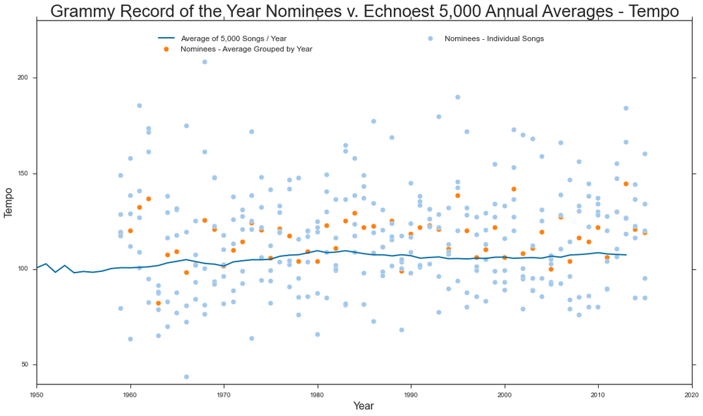

```python
z = mep.Year
plt.scatter(tdlavg['year'], tdlavg['avTempo'], facecolor=newcolours[1], s=60, label='Nominees - Average Grouped by Year')
plt.scatter(tempyr['year'], tempyr['tempo'], facecolor=newcolours[3], s=60, label='Nominees - Individual Songs')
plt.plot(z, mep.AvTempo, color=newcolours[0], label='Average of 5,000 Songs / Year')
rcParams['figure.figsize'] = 15, 10
plt.title('Grammy Record of the Year Nominees v. Echnoest 5,000 Annual Averages - Tempo')
sns.axlabel('Year', 'Tempo')
v=(1950, 2020, 40, 230)
plt.axis(v)
plt.axhline(y=0.5, color='black')
plt.axvline(x=0.5, color='black')
plt.legend(bbox_to_anchor=(0.18, 0.90, 0.6, 0.25), loc=3,
           ncol=2, mode="expand", borderaxespad=0.1, fontsize=12)
```

Our nominees cover a wide range, from The Beatles 1966 song "Yesterday" (44 bpm) to The 5th Dimension hit "Up, Up & Away" (208 bpm). Approximately two thirds of our individual nominees have tempos above the EchoNest yearly average. When grouping our nominees by year and averaging these, we can see that in most cases our average tempos sit above the EchoNest 5,000 song averages.

Although there are a few years where all nominees sit below or just on the EchoNest average (e.g. 1963 and 2005) it appears that songs with tempos above the average (when compared to EchoNest's data) are more likely to receive nominations.

We can also assess our nominated songs and their danceability. This is a slightly subjective measure, with 1 indicating high danceability and 0 indicating that lying on the couch and listening to the song might be more preferable.

Our songs have a wide range of danceability, with a peak around the low-to-mid 0.60's and a lesser peak in the low 0.50's:

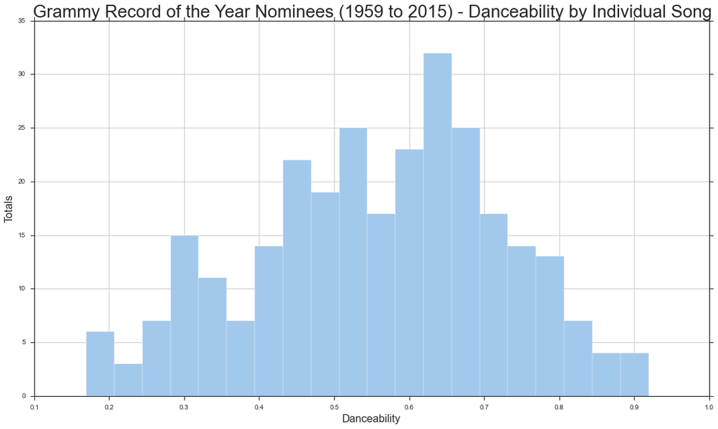

```python
rcParams['figure.figsize'] = 18, 10
tempyr.hist('danceability', facecolor=newcolours[3], bins=20)
plt.title('Grammy Record of the Year Nominees (1959 to 2015) - Danceability by Individual Song')
sns.axlabel('Danceability', 'Totals')
```

The EchoNest have also compiled a histogram of danceability. The chart below summarises the data for over 14 million songs:

```python
HTML('<iframe src=http://dl.dropbox.com/u/18669244/runningwithdata/danceability_histogram_50k.png width=800 height=600></iframe>')
#Source: http://runningwithdata.com/post/1321504427/danceability-and-energy
```

[interactive chart not shown]

```python
tempyr.danceability.describe()
```

```
count    285.000000
mean       0.558424
std        0.163996
min        0.169404
25%        0.449439
50%        0.567496
75%        0.680376
max        0.918835
Name: danceability, dtype: float64
```

Whilst the EchoNest data is reasonably normally distributed, our song data is slightly skewed with a tail to the left. Our song data also peaks in the low-to-mid 0.6 region, whereas EchoNest's histogram shows a peak around 0.5. 75% of our songs fall between 0.17 and 0.68 on the danceability scale, with 50% clustered between 0.45 and 0.68.

The chart below shows that the danceability rating of our songs appears to have trended upwards since 1959. We could argue that danceability can be a positive factor in securing a Record of the Year nomination:

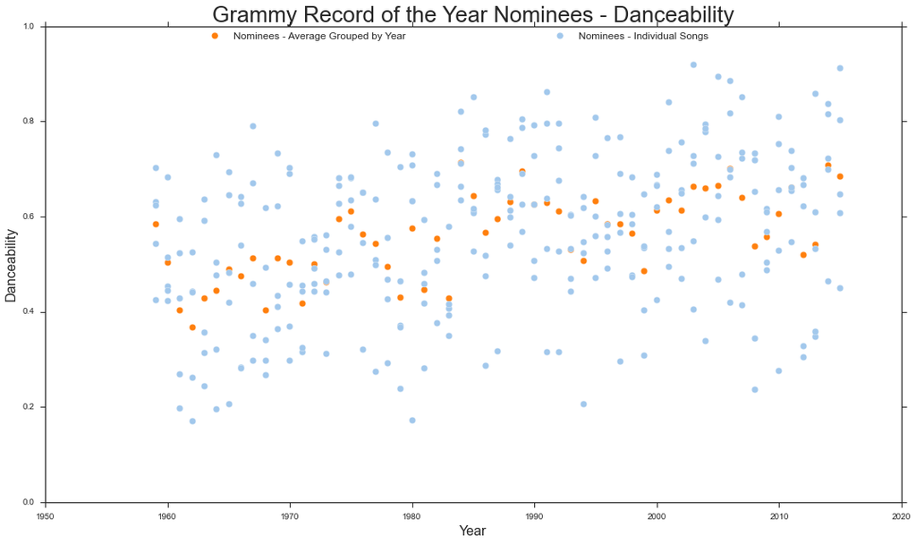

```python
plt.scatter(tdlavg['year'], tdlavg['avDanceability'], facecolor=newcolours[1], s=60, label='Nominees - Average Grouped by Year')
plt.scatter(tempyr['year'], tempyr['danceability'], facecolor=newcolours[3], s=60, label='Nominees - Individual Songs')
rcParams['figure.figsize'] = 15, 10
plt.title('Grammy Record of the Year Nominees - Danceability')
sns.axlabel('Year', 'Danceability')
v=(1950, 2020, 0, 1)
plt.axis(v)
plt.legend(bbox_to_anchor=(0.18, 0.96, 0.6, 0.25), loc=3,
           ncol=2, mode="expand", borderaxespad=0.1, fontsize=12)
```

One of the more controversial subjects in the music industry has been the increase in loudness, particularly since the advent of compact discs in the 1990's. Loudness in this context doesn't just mean the volume music is listened to; the EchoNest summarise it as "by compressing softer and louder sounds within each song into a smaller area – basically, amping up the softest instances to make them closer to the loudest instances – and then cramming that narrower band of loudness right up against the maximum a particular format can take. Although it reduces dynamic range (the distance between the loudest and softest sound you hear on a given recording), the overall effect is to create a perception that the song is louder."

Our chart below compares EchoNest's 5,000 top songs per year since 1950 to our Grammy nominated works:

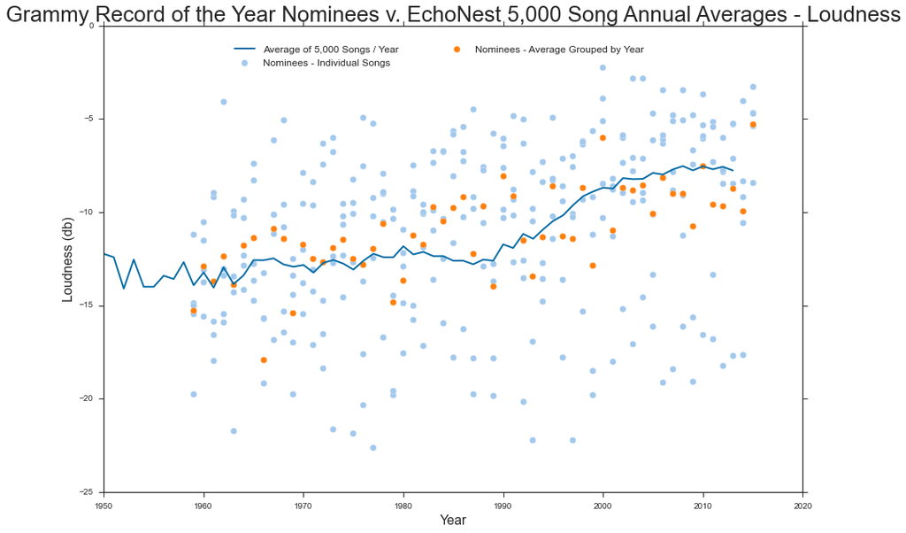

```python
ampit = pd.read_excel("EchoNestData.xlsx", "Loudness")
#Source: http://blog.echonest.com/post/62248127937/the-loudness-war-is-real-and-we-can-prove-it-with

z = ampit.Year

plt.scatter(tempyr['year'], tempyr['loudness'], facecolor=newcolours[3], s=60, label='Nominees - Individual Songs')
plt.scatter(tdlavg['year'], tdlavg['avLoudness'], facecolor=newcolours[1], s=60, label='Nominees - Average Grouped by Year')
plt.plot(z, ampit.AvLoudness, color=newcolours[0], label='Average of 5,000 Songs / Year')
rcParams['figure.figsize'] = 15, 10
plt.title('Grammy Record of the Year Nominees v. EchoNest 5,000 Song Annual Averages - Loudness')
sns.axlabel('Year', 'Loudness (db)')
v=(1950, 2020, -25, 0)
plt.axis(v)
plt.legend(bbox_to_anchor=(0.18, 0.90, 0.6, 0.25), loc=3,
           ncol=2, mode="expand", borderaxespad=0.1, fontsize=12)
```

The Echonest data shows an increase in loudness, in particular since 1990. The loudness of nominated songs has generally increased in line with the EchoNest average. However, we still have clusters well below the EchoNest average and this skews our averages somewhat.

We can compare our winning and nominated but non-winning songs below:

```python
loudwin = pd.read_sql("SELECT year, loudness FROM works w, songs s WHERE w.echo_SONGID=s.echo_SONGID AND w.winner=1", con=engine)
loudnom = pd.read_sql("SELECT year, loudness FROM works w, songs s WHERE w.echo_SONGID=s.echo_SONGID AND w.winner=0", con=engine)
```

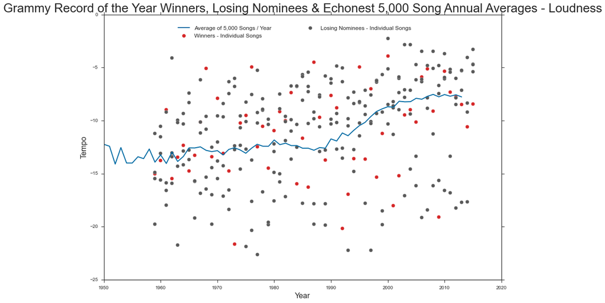

```python
z = ampit.Year
plt.scatter(loudwin['year'], loudwin['loudness'], facecolor=newcolours[8], s=60, label='Winners - Individual Songs')
plt.scatter(loudnom['year'], loudnom['loudness'], facecolor=newcolours[4], s=60, label='Losing Nominees - Individual Songs')
plt.plot(z, ampit.AvLoudness, color=newcolours[0], label='Average of 5,000 Songs / Year')
rcParams['figure.figsize'] = 15, 10
plt.title('Grammy Record of the Year Winners, Losing Nominees & Echonest 5,000 Song Annual Averages - Loudness')
sns.axlabel('Year', 'Tempo')
v=(1950, 2020, -25, 0)
plt.axis(v)
plt.legend(bbox_to_anchor=(0.18, 0.90, 0.6, 0.25), loc=3,
           ncol=2, mode="expand", borderaxespad=0.1, fontsize=12)
```

Loudness and year have a slight correlation, however the correlation appears to be stronger for nominees and year than it is for winning songs and year. The EchoNest data shows a levelling off of loudness in the late 2000's, followed by a slight decline in 2013, the latter of which could in part be attributed to Apple's decision to undertake peak limiting of songs.

# Song Length

The final song characteristic to assess is the length of the song itself. As previously discussed, there has been much discussion around what the optimal song length should be. Opinions range but appear to be centered around the 3 minute mark. (Source: https://www.google.co.nz/webhp?sourceid=chrome-instant&ion=1&espv=2&ie=UTF-8#q=optimal+song+length+). We can group our songs by year, and also look at whether there are any differences between winners and losers:

```python
songlenav = pd.read_sql("SELECT year, AVG(song_length) as avSongLength FROM works w, songs s WHERE w.echo_SONGID=s.echo_SONGID GROUP BY w.year", con=engine)
songlenall = pd.read_sql("SELECT year, work, song_length FROM works w, songs s WHERE w.echo_SONGID=s.echo_SONGID", con=engine)
songlenwin = pd.read_sql("SELECT year, work, song_length FROM works w, songs s WHERE w.echo_SONGID=s.echo_SONGID AND w.winner=1", con=engine)
songlenlose = pd.read_sql("SELECT year, work, song_length FROM works w, songs s WHERE w.echo_SONGID=s.echo_SONGID AND w.winner=0", con=engine)
```

The chart below groups our songs by year then averages the song lengths. We can see that only 9 of our 57 yearly averages are approximately 180 seconds (3 minutes) or below in length:

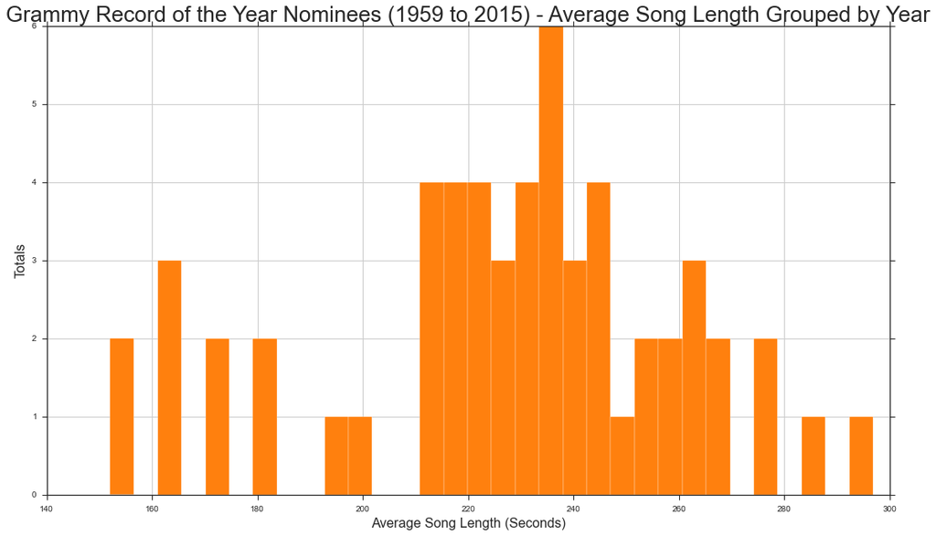

```python
rcParams['figure.figsize'] = 18, 10
songlenav.hist('avSongLength', facecolor=newcolours[1], bins=32)
plt.title('Grammy Record of the Year Nominees (1959 to 2015) - Average Song Length Grouped by Year')
sns.axlabel('Average Song Length (Seconds)', 'Totals')
```

If we plot the same data on a yearly basis (orange line), we can see that average song length was fairly stable until 1969, when it increased dramatically. This then dropped slightly and remained stable (with a few peaks due to outliers) until the late 2000's, when it appeared that songs began to decrease in length slightly. With the exception of 2008, the average of which is skewed by an outlier, song lengths appear to be decreasing:

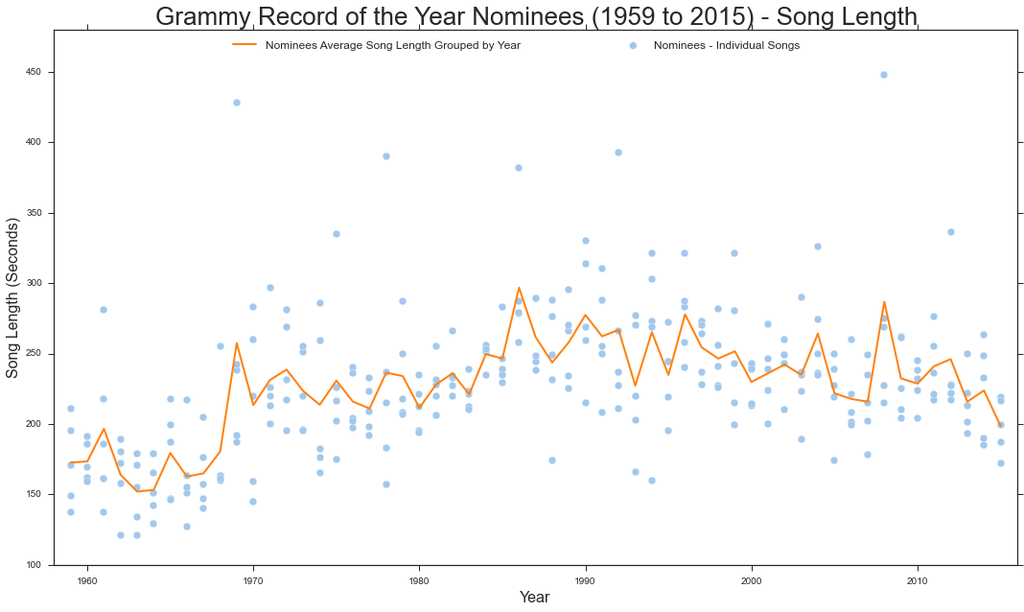

```python
x = songlenav.year
plt.title('Grammy Record of the Year Nominees (1959 to 2015) - Song Length')
plt.scatter(songlenall['year'], songlenall['song_length'], facecolor=newcolours[3], s=60, label='Nominees - Individual Songs')
plt.plot(x, songlenav.avSongLength, color=newcolours[1], label='Nominees Average Song Length Grouped by Year')
v=(1958, 2016, 100, 480)
plt.axis(v)
sns.axlabel('Year', 'Song Length (Seconds)')
plt.legend(bbox_to_anchor=(0.18, 0.95, 0.6, 0.25), loc=3,
           ncol=2, mode="expand", borderaxespad=0.1, fontsize=12)
```

The plot below shows the same yearly average song lengths plotted alongside individual song data, with winners in red and losers in charcoal.

Over the years, song length does not appear to have been a strong determinant in whehter a nominated song is a winner or loser. One point to note however is the length of winning songs has declined from their peak in the late 1980's through the 1990's. From 2000 onwards (with the exception of 2006) winning songs have not been the longest of those nominated.

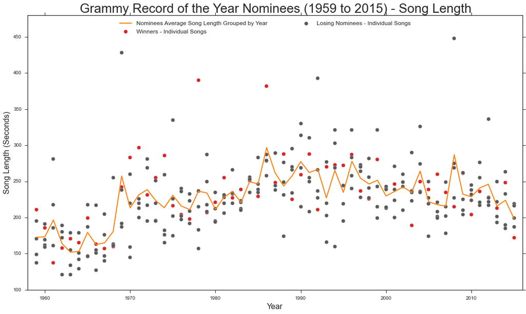

```python
x = songlenav.year
plt.title('Grammy Record of the Year Nominees (1959 to 2015) - Song Length')
plt.scatter(songlenwin['year'], songlenwin['song_length'], facecolor=newcolours[8], s=60, label='Winners - Individual Songs')
plt.scatter(songlenlose['year'], songlenlose['song_length'], facecolor=newcolours[4], s=60, label='Losing Nominees - Individual Songs')
plt.plot(x, songlenav.avSongLength, color=newcolours[1], label='Nominees Average Song Length Grouped by Year')
v=(1958, 2016, 100, 480)
plt.axis(v)
sns.axlabel('Year', 'Song Length (Seconds)')
plt.legend(bbox_to_anchor=(0.18, 0.92, 0.6, 0.25), loc=3,
           ncol=2, mode="expand", borderaxespad=0.1, fontsize=12)
```

# **3. Data Analysis - Success in the UK Charts**

We turn now to our UK chart data, which is based upon actual sales of individual records (songs) as opposed to the inclusion of airplay. We can read in the following data and then make decisions on how best to approach the analysis of this.

```python
ukcharts = pd.read_sql("SELECT year, work, wks_in_chart, wks_in_top40, wks_in_top10, wks_highest_pos, high_pos FROM works w, charts c WHERE w.echo_SONGID=c.echo_SONGID", con=engine)
ukcharts.head()
```

|  | year | work | wks_in_chart | wks_in_top40 | wks_in_top10 | wks_highest_pos | high_pos |
| --- | --- | --- | --- | --- | --- | --- | --- |
| 0 | 1980 | I Will Survive | 15 | 12 | 9 | 4 | 1 |
| 1 | 1961 | Are You Lonesome Tonight? | 15 | 14 | 7 | 4 | 1 |
| 2 | 1994 | The River Of Dreams | 14 | 12 | 6 | 1 | 3 |
| 3 | 1997 | Because You Loved Me | 16 | 14 | 8 | 4 | 5 |
| 4 | 1976 | Lyin' Eyes | 7 | 6 | 0 | 3 | 23 |

Firstly, we can quickly ascertain how many of our Grammy nominees actually entered the UK charts:

```python
ukcharts[(ukcharts['wks_in_chart'] > 0)].count()
```

```
year               256
work               256
wks_in_chart       256
wks_in_top40       256
wks_in_top10       256
wks_highest_pos    256
high_pos           256
dtype: int64
```

Then plot this data:

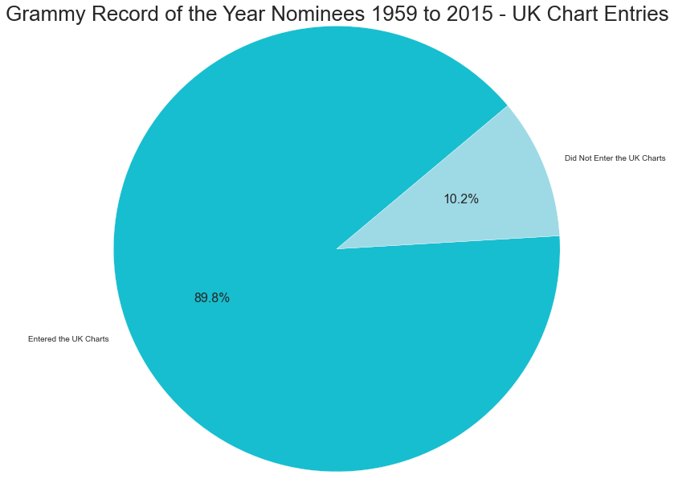

```python
labels = ['Entered the UK Charts', 'Did Not Enter the UK Charts']
sizes = [256, 29]
plt.title('Grammy Record of the Year Nominees 1959 to 2015 - UK Chart Entries')
rcParams['figure.figsize'] = 10, 10
plt.pie(sizes, labels=labels, colors=newcolours[13:],
        autopct='%1.1f%%', shadow=False, startangle=400,)
plt.axis('equal')
plt.show()
```

We can see that the majority of our nominees (256/285) entered the UK charts at some stage. Of those that didn't, the majority (23/29) of songs were released prior to 1980:

```python
noent = ukcharts[(ukcharts['wks_in_chart'] == 0)]
noentg = noent.groupby(['year'])
noentg.count()
```

| year | work | wks_in_chart | wks_in_top40 | wks_in_top10 | wks_highest_pos | high_pos |
| --- | --- | --- | --- | --- | --- | --- |
| 1959 | 1 | 1 | 1 | 1 | 1 | 1 |
| 1960 | 1 | 1 | 1 | 1 | 1 | 1 |
| 1962 | 2 | 2 | 2 | 2 | 2 | 2 |
| 1963 | 1 | 1 | 1 | 1 | 1 | 1 |
| 1964 | 3 | 3 | 3 | 3 | 3 | 3 |
| 1966 | 3 | 3 | 3 | 3 | 3 | 3 |
| 1967 | 2 | 2 | 2 | 2 | 2 | 2 |
| 1968 | 2 | 2 | 2 | 2 | 2 | 2 |
| 1970 | 3 | 3 | 3 | 3 | 3 | 3 |
| 1974 | 1 | 1 | 1 | 1 | 1 | 1 |
| 1975 | 1 | 1 | 1 | 1 | 1 | 1 |
| 1977 | 2 | 2 | 2 | 2 | 2 | 2 |
| 1979 | 1 | 1 | 1 | 1 | 1 | 1 |
| 1981 | 1 | 1 | 1 | 1 | 1 | 1 |
| 1992 | 1 | 1 | 1 | 1 | 1 | 1 |
| 2005 | 2 | 2 | 2 | 2 | 2 | 2 |
| 2009 | 1 | 1 | 1 | 1 | 1 | 1 |
| 2012 | 1 | 1 | 1 | 1 | 1 | 1 |

```python
noenty = pd.read_sql("SELECT year, work, winner, energy, valence, loudness, tempo, danceability, wks_in_chart FROM works w, songs s, charts c WHERE w.echo_SONGID=s.echo_SONGID AND w.echo_SONGID=c.echo_SONGID AND c.wks_in_chart=0", con=engine)
noenty[(noenty['winner'] == 0)].count()
```

```
year            23
work            23
winner          23
energy          23
valence         23
loudness        23
tempo           23
danceability    23
wks_in_chart    23
dtype: int64
```

We can also create a pivot table to see if there are marked variances between winning and non-winning non-charting songs:

```python
noenty.pivot_table(index=['winner'])
```

| winner | danceability | energy | loudness | tempo | valence | wks_in_chart | year |
| --- | --- | --- | --- | --- | --- | --- | --- |
| 0 | 0.470656 | 0.378319 | -13.227000 | 104.703478 | 0.481368 | 0 | 1972.73913 |
| 1 | 0.454975 | 0.373453 | -12.055667 | 110.412333 | 0.420795 | 0 | 1981.50000 |

We will now turn our focus to those that did chart to see if we can gain further insight. Firstly, we can group our charting nominees by year:

```python
dident = ukcharts[(ukcharts['wks_in_chart'] > 0)]
didentg = dident.groupby(['year'])
didentg.mean()
```

| year | wks_in_chart | wks_in_top40 | wks_in_top10 | wks_highest_pos | high_pos |
| --- | --- | --- | --- | --- | --- |
| 1959 | 10.250000 | 8.250000 | 2.000000 | 1.00 | 9.000000 |
| 1960 | 15.250000 | 5.250000 | 9.500000 | 2.50 | 2.500000 |
| 1961 | 15.000000 | 12.000000 | 2.800000 | 1.60 | 12.200000 |
| 1962 | 10.333333 | 8.666667 | 4.000000 | 1.00 | 17.333333 |
| 1963 | 13.000000 | 10.500000 | 2.750000 | 1.75 | 15.750000 |
| 1964 | 7.500000 | 6.500000 | 3.000000 | 1.50 | 18.500000 |
| 1965 | 11.800000 | 8.800000 | 4.600000 | 2.20 | 22.000000 |
| 1966 | 11.000000 | 10.500000 | 5.000000 | 1.00 | 4.500000 |
| 1967 | 17.333333 | 16.000000 | 7.000000 | 2.00 | 2.666667 |
| 1968 | 11.333333 | 8.333333 | 6.666667 | 1.00 | 21.666667 |
| ... | ... | ... | ... | ... | ... |
| 2006 | 31.000000 | 15.000000 | 5.600000 | 1.40 | 3.800000 |
| 2007 | 21.000000 | 11.000000 | 6.000000 | 3.40 | 21.200000 |
| 2008 | 42.800000 | 20.800000 | 5.400000 | 3.00 | 4.800000 |
| 2009 | 29.000000 | 15.750000 | 5.500000 | 3.00 | 5.750000 |
| 2010 | 54.600000 | 24.600000 | 10.200000 | 1.80 | 7.600000 |
| 2011 | 31.800000 | 20.000000 | 5.800000 | 2.00 | 6.800000 |
| 2012 | 42.250000 | 18.250000 | 7.000000 | 1.25 | 9.250000 |
| 2013 | 27.200000 | 14.600000 | 7.200000 | 2.20 | 39.600000 |
| 2014 | 45.200000 | 23.200000 | 8.400000 | 2.80 | 3.400000 |
| 2015 | 37.600000 | 31.600000 | 8.000000 | 1.60 | 3.000000 |

57 rows × 5 columns

Then plot this data:

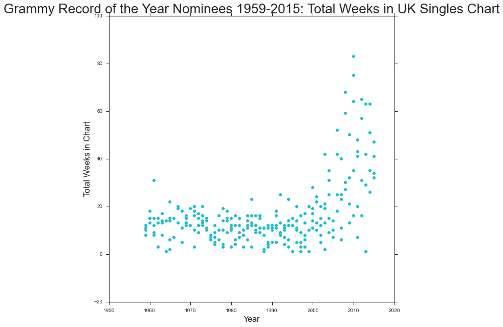

```python
plt.scatter(dident['year'], dident['wks_in_chart'], facecolor=newcolours[13], s=40)
rcParams['figure.figsize'] = 15, 8
plt.title('Grammy Record of the Year Nominees 1959-2015: Total Weeks in UK Singles Chart')
sns.axlabel('Year', 'Total Weeks in Chart')
```

(Note: 2015 songs are still charting. These chart figures are as at 18 April 2015).

Until approximately 2000 we can see that nominated songs tended to spend between 1 and 20 weeks in the UK singles chart. Around 2000 we start to see a change in the data, with a larger spread of results (Lady Gaga's "Poker Face" spent 83 consecutive weeks in the charts with Black Eyed Peas' "I Gotta Feeling" in the charts for 75 consecutive weeks).

From 2006 onwards, we see that all but three of the charting nominees spent at least 10 consecutive weeks in the charts (the exceptions being "Not Ready to Make Nice" in 2007, "Lonely Boy" (2013) and "Thinkin Bout You" (also 2013)). There is a definitive upswing in chart longevity; this can be attributed in part to the increase in digital sales (so sales are easier to track) and greater rigour around point of sale data in stores. There have also been studies done which measured liklihood of download if a "top list" was visible when selecting songs. These conclusively showed that rankings did affect downloads as people naturally gravitated to already popular songs. Even when the rankings were flipped - so the truly lowest ranked was noted as being at the top - then this same behaviour persisted with the least popular songs suddenly becoming popular [Source: http://www.theatlantic.com/magazine/archive/2014/12/the-shazam-effect/382237/]. It could also be that a Grammy nomination effectively acts as advertising; in the age of social media and advanced communications technology if sufficient buzz is generated then people may be induced to listen to and then purchase the song.

We do have all UK singles chart data from 1952 to 1999 courtesy of The Britburn Project. If we read in our Excel file we can then compare this with our nominee data to see if there are any similarities or differences:

```python
teak = pd.read_excel("britburn.xls")
teek = pd.DataFrame(teak, columns=['Year', 'CH', '40', '10', '#' 'High'])
teek.info()
```

```
<class 'pandas.core.frame.DataFrame'>
Int64Index: 29027 entries, 0 to 29026
Data columns (total 5 columns):
Year     29027 non-null int64
CH       29027 non-null int64
40       29026 non-null object
10       29026 non-null object
#High    0 non-null float64
dtypes: float64(1), int64(2), object(2)
memory usage: 1.1+ MB
```

The chart below shows that we have a large number of songs that charted for one to two weeks, then exited the charts. The table beneath that shows that 207 of our 29027 charting UK singles over the period remained in the charts in excess of 20 weeks:

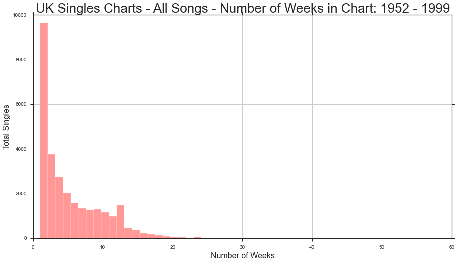

```python
teek.hist('CH', facecolor=newcolours[9], bins=50)
rcParams['figure.figsize'] = 15, 8
plt.title('UK Singles Charts - All Songs - Number of Weeks in Chart: 1952 - 1999')
sns.axlabel('Number of Weeks', 'Total Singles')
```

```python
taak = teek[(teek['CH'] > 20)]
taak.count()
```

```
Year     207
CH       207
40       207
10       207
#High      0
dtype: int64
```

If we exclude post-2000 nominees, we can see that if our Grammy nominated songs entered the charts they tended to have greater chart longevity then the population of charting singles. It could be argued that a Grammy nomination is positively correlated with chart longevity, although it is unclear if the nomination contributed to chart success or if chart success contributed to the liklihood of nomination:

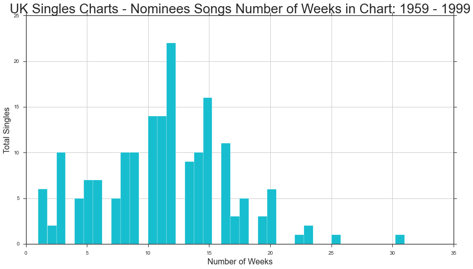

```python
dident1 = dident[(dident['year'] < 2000)]
dident1.hist('wks_in_chart', facecolor=newcolours[13], bins=40)
rcParams['figure.figsize'] = 15, 8
plt.title('UK Singles Charts - Nominees Songs Number of Weeks in Chart: 1959 - 1999')
sns.axlabel('Number of Weeks', 'Total Singles')
```

We can now consider if winning songs chart behaviour is different to that of losing nominees. The pivot table below shows that on average, losing nominees attained a higher position in the charts than winning songs:

```python
didentplus = pd.read_sql("SELECT year, work, winner, wks_in_chart, high_pos FROM works w, charts c WHERE w.echo_SONGID=c.echo_SONGID AND c.wks_in_chart>0", con=engine)
didentplus.pivot_table(index=['winner'])
```

| winner | high_pos | wks_in_chart | year |
| --- | --- | --- | --- |
| 0 | 12.770732 | 16.482927 | 1988.600000 |
| 1 | 15.294118 | 16.862745 | 1987.647059 |

This is also shown in the plot below - the lower the number the higher the placement (i.e. 1 is good, 99 not so good):

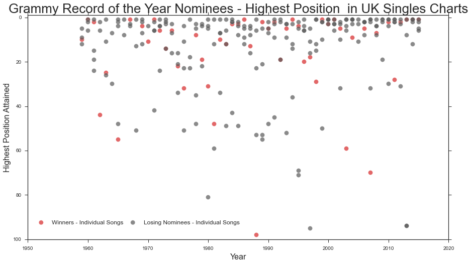

```python
didentwin = didentplus[(didentplus['winner'] == 1)]
didentlose = didentplus[(didentplus['winner'] == 0)]

plt.scatter(didentwin['year'], didentwin['high_pos'], facecolor=newcolours[8], s=80, alpha=0.7, label='Winners - Individual Songs')
plt.scatter(didentlose['year'], didentlose['high_pos'], facecolor=newcolours[4], s=80, alpha=0.7, label='Losing Nominees - Individual Songs')
rcParams['figure.figsize'] = 15, 10
plt.title('Grammy Record of the Year Nominees - Highest Position  in UK Singles Charts')
sns.axlabel('Year', 'Highest Position Attained')
v=(1950, 2020, 100, -1)
plt.axis(v)
plt.legend(bbox_to_anchor=(0.01, 0.05, 0.5, 0.25), loc=3,
           ncol=2, mode="expand", borderaxespad=0.1, fontsize=12)
```

In addition, the chart below shows that winning the award doesn't necessarily mean that the song had greater longevity than its fellow nominees. However, we can see that 2009-15 (excluding 2011) our winning songs tended to chart well in comparison with their non-winning fellow nominees. (Note: 2015 songs are still charting. These chart figures are as at 18 April 2015):

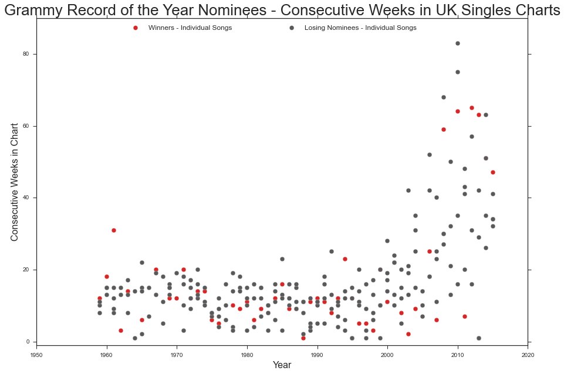

```python
didentwin = didentplus[(didentplus['winner'] == 1)]
didentlose = didentplus[(didentplus['winner'] == 0)]

plt.scatter(didentwin['year'], didentwin['wks_in_chart'], facecolor=newcolours[8], s=60, label='Winners - Individual Songs')
plt.scatter(didentlose['year'], didentlose['wks_in_chart'], facecolor=newcolours[4], s=60, label='Losing Nominees - Individual Songs')
rcParams['figure.figsize'] = 15, 10
plt.title('Grammy Record of the Year Nominees - Consecutive Weeks in UK Singles Charts')
sns.axlabel('Year', 'Consecutive Weeks in Chart')
v=(1950, 2020, -1, 90)
plt.axis(v)
plt.legend(bbox_to_anchor=(0.18, 0.95, 0.6, 0.25), loc=3,
           ncol=2, mode="expand", borderaxespad=0.1, fontsize=12)
```

# **4. Data Analysis - Song Title and Artist Name Analysis**

We can now assess our song titles and artist names. Firstly, we can read in the data:

```python
words = pd.read_sql("SELECT year, winner, work, work_chars, work_words, artist, artist_chars, artist_words FROM works w, artists a WHERE w.echo_SONGID=a.echo_SONGID", con=engine)
words.head()
```

|  | year | winner | work | work_chars | work_words | artist | artist_chars | artist_words |
| --- | --- | --- | --- | --- | --- | --- | --- | --- |
| 0 | 1980 | 0 | I Will Survive | 14 | 3 | Gloria Gaynor | 13 | 2 |
| 1 | 1961 | 0 | Are You Lonesome Tonight? | 25 | 4 | Elvis Presley | 13 | 2 |
| 2 | 1994 | 0 | The River Of Dreams | 19 | 4 | Billy Joel | 10 | 2 |
| 3 | 1997 | 0 | Because You Loved Me | 20 | 4 | Celine Dion | 11 | 2 |
| 4 | 1976 | 0 | Lyin' Eyes | 10 | 2 | Eagles | 6 | 1 |

"work_chars"/"artist_chars" equates to the number of characters (including whitespace) in the song title/artist's name.

# Correlations - Character & Word Length

Firstly, if we plot the number of characters in each work, we can see a slight negative correlation between the number of characters and year the song was nominated:

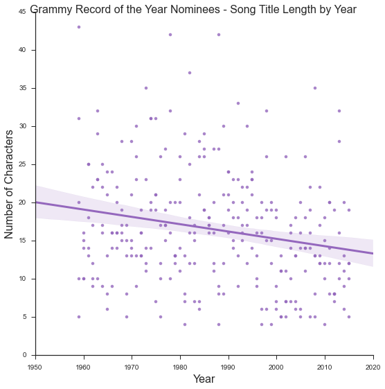

```python
wkchar = sns.lmplot("year", "work_chars", data=words,
              color=newcolours[10], size=8)
wkchar.set_axis_labels("Year", "Number of Characters")
wkchar.fig.suptitle('Grammy Record of the Year Nominees - Song Title Length by Year')
```

For artists, there appears to be no correlation between year of nomination and length of the artist's name. In more recent times we can see a greater spread of length of name; there have been a number of nominations made in recent times to collaborations between artists (e.g. Artist A featuring Artist B etc.). This lengthens the artist name.

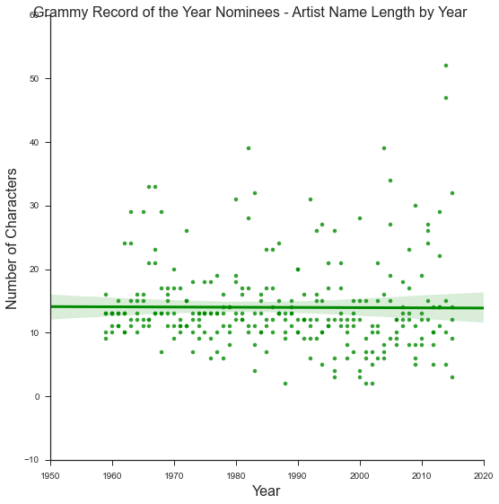

```python
wkchar = sns.lmplot("year", "artist_chars", data=words,
              color=newcolours[12], size=8)
wkchar.set_axis_labels("Year", "Number of Characters")
wkchar.fig.suptitle('Grammy Record of the Year Nominees - Artist Name Length by Year')
```

We can then look at correlation plots to see if there are any differences between winning and non-winning nominees:

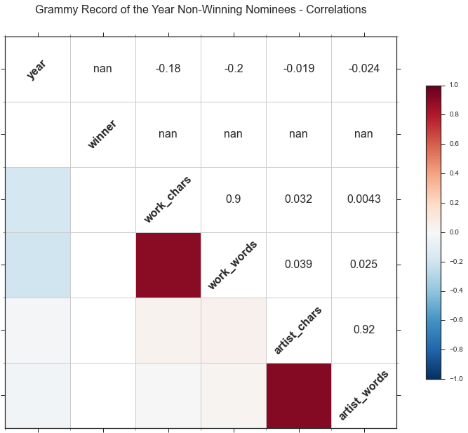

```python
wordnowin = words[(words['winner'] == 0)]
sns.corrplot(wordnowin, cmap='RdBu_r',)
sns.set_context(rc={"figure.figsize": (9, 9)})
plt.title('Grammy Record of the Year Non-Winning Nominees - Correlations', fontsize=16)
```

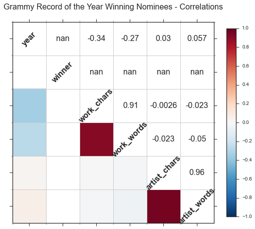

```python
wordwin = words[(words['winner'] == 1)]
sns.corrplot(wordwin, cmap='RdBu_r',)
sns.set_context(rc={"figure.figsize": (9, 9)})
plt.title('Grammy Record of the Year Winning Nominees - Correlations', fontsize=16)
```

The plots show the expected strong correlations (i.e. between number of characters/words in a song title/artist name). There is also the previously shown negative correlation between year and number of characters in a song title. However, these do differ between winning and non-winning nominees with the negative correlation being stronger for winners (-0.34) than non-winners (-0.18). There is also a slightly positive correlation between year and number of words in an artist name for winners (0.057), and a slightly negative correlation for the same parameters with non-winners (-0.024).

# Language Analysis

We can now turn to the words used in song titles to see if there are any common features. Excepting "Volare", "Desafinado", "Livin' La Vida Loca" and "Viva La Vida" the remainder of our song titles are in English.

Firstly, we pass can import some of the modules from nltk, a language processor, then pass our variable "work" and its contents to a set called results. From there, we can tokenize, strip out the punctation and then format this data as nltk text.

We can then use nltk's Frequency Distribution to assess the frequency distribution of the words within our song titles:

```python
from nltk import probability, ConditionalFreqDist
from nltk import word_tokenize
from __future__ import division
from nltk.tokenize import RegexpTokenizer
from collections import Counter

results = set(words.work)

single = nltk.word_tokenize(str(results))
tokenizer = RegexpTokenizer(r'\w+')
sin = tokenizer.tokenize(str(single))
wktext = nltk.Text((sin))
nltk.FreqDist(wktext)
```

```
FreqDist({'The': 49, 'You': 33, 'I': 26, 'Of': 22, 'Love': 21, 'A': 16, 'To': 16, 'Me': 15, 'My': 14, 'In': 14, ...})
```

This shows us that some of our common words such as "the" and "a" are present. As they confuse our analysis of the song titles we can create our own stopwords list, remove these from our nltk text, then plot the results:

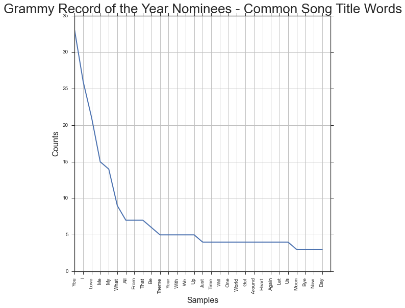

```
FreqDist({'You': 33, 'I': 26, 'Love': 21, 'Me': 15, 'My': 14, 'What': 9, 'All': 7, 'From': 7, 'That': 7, 'Be': 6, ...})
```

```python
stopwords = ['The', 'Of', 'A', 'To', 'In', 'a', 'On', 'And', 'Is', 'It', 'n', "'n'", 'For', 'Do', 'Are', 't', 's', 'nt', 're', 'll']
wtxt = [i for i in wktext if i not in stopwords]
wtxt = nltk.Text((wtxt))
plt.title('Grammy Record of the Year Nominees - Common Song Title Words')
wtxt.plot(30)
wtxt.vocab()
```

The top 5 words (excluding stopwords) are either pronouns (you, I, me, my) or the word "love"; all very simple words in the English language.

If we look at the word "love", we can assess how many variants of this are present in the song titles. This gives us a total of 25:

```python
sorted(w for w in wtxt if w.startswith('Lov'))
```

```
['Love',
 'Love',
 'Love',
 'Love',
 'Love',
 'Love',
 'Love',
 'Love',
 'Love',
 'Love',
 'Love',
 'Love',
 'Love',
 'Love',
 'Love',
 'Love',
 'Love',
 'Love',
 'Love',
 'Love',
 'Love',
 'Loved',
 'Lover',
 'Lovers',
 'Loving']
```

Our frequency plot above also shows us that of the top 30 most common words (excluding our stopwords), the longest word has six letters ("around"). Reginald Smith, writing in Glottometrics, has studied the frequency of distinct words by length. Smith indicates that the average length of a word in the English language is 9.2 characters and the most common length is approximately 8 characters. [Source: http://arxiv.org/ftp/arxiv/papers/1207/1207.2334.pdf]

Below we can see the conditional frequency distributions of words within our song titles (again excluding stopwords). Shorter words are popular and more common than longer words. If we look at some of our longer words, we see that these are less utilised:

```python
cfdist = ConditionalFreqDist()
for word in wtxt:
    condition = len(word)
    cfdist[condition][word] += 1
cfdist[4], cfdist[5], cfdist[6], cfdist[7], cfdist[8], cfdist[9], cfdist[10], cfdist[11], cfdist[12], cfdist[13]
```

```
(FreqDist({'Love': 21, 'What': 9, 'From': 7, 'That': 7, 'Your': 5, 'With': 5, 'Just': 4, 'Time': 4, 'Will': 4, 'Blue': 3, ...}),
 FreqDist({'Theme': 5, 'World': 4, 'Heart': 4, 'Again': 4, 'River': 3, 'Night': 3, 'Crazy': 3, 'Happy': 2, 'Brown': 2, 'Leave': 2, ...}),
 FreqDist({'Around': 4, 'Heaven': 3, 'Belong': 2, 'Monday': 2, 'Dreams': 2, 'Summer': 2, 'Always': 2, 'Living': 1, 'Lovers': 1, 'Harper': 1, ...}),
 FreqDist({'Without': 3, 'Nothing': 2, 'Believe': 2, 'Feeling': 2, 'Jackson': 1, 'Lineman': 1, 'Dancing': 1, 'Thinkin': 1, 'Dipinto': 1, 'Looking': 1, ...}),
 FreqDist({'Sunshine': 2, 'Paradise': 2, 'Somebody': 2, 'Together': 2, 'American': 2, 'Somethin': 1, 'Addicted': 1, 'Compares': 1, 'Troubled': 1, 'Thousand': 1, ...}),
 FreqDist({'Beautiful': 3, 'Evergreen': 1, 'Seventeen': 1, 'Boulevard': 1, 'Hollaback': 1, 'Innocence': 1, 'Yesterday': 1, 'Strangers': 1, 'Afternoon': 1, 'Francisco': 1, ...}),
 FreqDist({'Everything': 2, 'Flashdance': 1, 'Winchester': 1, 'Witchcraft': 1, 'Masquerade': 1, 'Desafinado': 1, 'Rhinestone': 1, 'Chandelier': 1, 'California': 1, 'Waterfalls': 1}),
 FreqDist({'Radioactive': 1}),
 FreqDist({'Sledgehammer': 1, 'Philadelphia': 1}),
 FreqDist({'Irreplaceable': 1, 'Unforgettable': 1}))
```

Our overall count below provides a summary of the types of words used in our song titles. The better utilised tend to have more positive overtones (excepting "Go" and "Bye" with a frequency of three - however the three "Bye"'s are from one song title, "Bye Bye Bye" by *NSYNC):

```python
Counter(wtxt)
```

```
Counter({'You': 33, 'I': 26, 'Love': 21, 'Me': 15, 'My': 14, 'What': 9, 'All': 7, 'From': 7, 'That': 7, 'Be': 6, 'Theme': 5, 'Your': 5, 'With': 5, 'We': 5, 'Up': 5, 'Just': 4, 'Time': 4, 'Will': 4, 'One': 4, 'World': 4, 'Got': 4, 'Around': 4, 'Heart': 4, 'Again': 4, 'Let': 4, 'Us': 4, 'Moon': 3, 'By…
```

From this, we could perhaps conclude that it is advantageous to have a song title with one or more:

```
**Common words that are easy to pronounce.
**A pronoun
**Mentioning love or one of its variants (including "heart") could potentially help
**Shorter rather than longer words
**Titles with less complexity?
**Keep it positive - adjectives like "beautiful" tended to be used more often than less positive descriptors such as "lonesome" and                  "break".
```

# **5. Data Analysis - Summary**

We can read in our entire dataset again and perform a high level describe:

```python
everything = pd.read_sql("SELECT year, winner, work, work_chars, work_words, artist, artist_chars, artist_words, song_length, danceability, energy, loudness, tempo, time_signature, valence, wks_in_chart, wks_in_top40, wks_in_top10, wks_highest_pos, high_pos FROM works w, artists a, songs s, charts c WHERE w.echo_SONGID=a.echo_SONGID AND w.echo_SONGID=s.echo_SONGID AND w.echo_SONGID=c.echo_SONGID", con=engine)
everything.describe()
```

|  | year | winner | work_chars | work_words | artist_chars | artist_words | song_length | danceability | energy | loudness | tempo | time_signature | valence | wks_in_chart | wks_in_top40 | wks_in_top10 | wks_highest_pos | high_pos |
| --- | --- | --- | --- | --- | --- | --- | --- | --- | --- | --- | --- | --- | --- | --- | --- | --- | --- | --- |
| count | 285.000000 | 285.000000 | 285.000000 | 285.000000 | 285.000000 | 285.000000 | 285.000000 | 285.000000 | 285.000000 | 285.000000 | 285.000000 | 285.000000 | 285.000000 | 285.000000 | 285.000000 | 285.000000 | 285.000000 | 285.000000 |
| mean | 1987.000000 | 0.200000 | 16.459649 | 3.305263 | 13.985965 | 2.375439 | 227.305263 | 0.558424 | 0.514339 | -11.043698 | 116.264793 | 3.940351 | 0.532366 | 14.873684 | 9.757895 | 3.957895 | 1.610526 | 11.922807 |
| std | 16.480889 | 0.400704 | 7.530872 | 1.685107 | 7.075534 | 1.202738 | 49.278400 | 0.163996 | 0.225242 | 4.680893 | 27.364555 | 0.324938 | 0.247812 | 14.104171 | 8.161722 | 4.338452 | 1.680217 | 18.482796 |
| min | 1959.000000 | 0.000000 | 4.000000 | 1.000000 | 2.000000 | 1.000000 | 121.000000 | 0.169404 | 0.012796 | -25.857000 | 43.749000 | 1.000000 | 0.037615 | 0.000000 | 0.000000 | 0.000000 | 0.000000 | 0.000000 |
| 25% | 1973.000000 | 0.000000 | 11.000000 | 2.000000 | 10.000000 | 2.000000 | 198.000000 | 0.449439 | 0.339770 | -14.491000 | 94.985000 | 4.000000 | 0.349272 | 7.000000 | 3.000000 | 0.000000 | 1.000000 | 1.000000 |
| 50% | 1987.000000 | 0.000000 | 16.000000 | 3.000000 | 13.000000 | 2.000000 | 226.000000 | 0.567496 | 0.510144 | -10.154000 | 117.050000 | 4.000000 | 0.539422 | 12.000000 | 9.000000 | 3.000000 | 1.000000 | 4.000000 |
| 75% | 2001.000000 | 0.000000 | 20.000000 | 4.000000 | 16.000000 | 2.000000 | 255.000000 | 0.680376 | 0.684871 | -7.458000 | 132.729000 | 4.000000 | 0.729563 | 17.000000 | 14.000000 | 7.000000 | 2.000000 | 12.000000 |
| max | 2015.000000 | 1.000000 | 43.000000 | 8.000000 | 52.000000 | 8.000000 | 448.000000 | 0.918835 | 0.977037 | -2.268000 | 208.135000 | 5.000000 | 0.975778 | 83.000000 | 45.000000 | 21.000000 | 16.000000 | 98.000000 |

We can also plot a correlation matrix across our entire dataset:

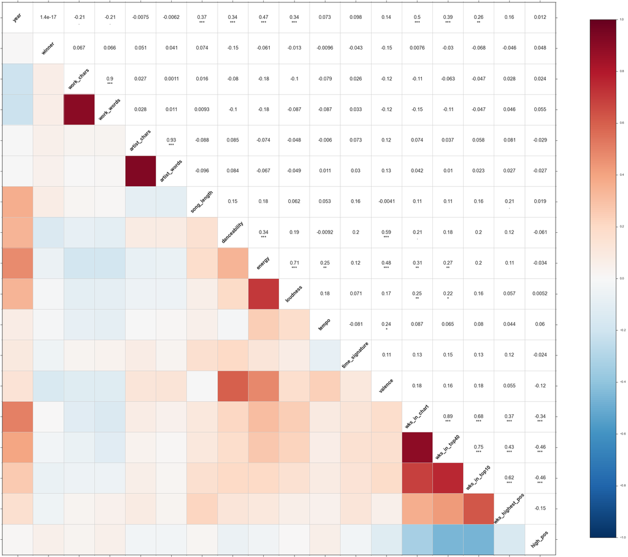

```python
sns.corrplot(everything, cmap='RdBu_r',)
sns.set_context(rc={"figure.figsize": (40, 40)})
```

A quick assessment provides a summary of some of the analysis previously documented in this report. There are the expected positive correlations - e.g. the higher the danceability rating the higher the valence, which is unsurprising given dancing to a sad song is perhaps less enjoyable than a happy one.

There is an interesting negative correlation between number of characters in a song title and the energy rating of the song (-0.18).

The high position / weeks in chart correlation figures need to be interpreted with care. Essentially, the lower the highest ever chart position (e.g. making number 1), the more likely the song is to have stayed in the charts for more than 5-6 weeks whereas a low chart position makes the song more likely to exit earlier. This is charted below for clarity:

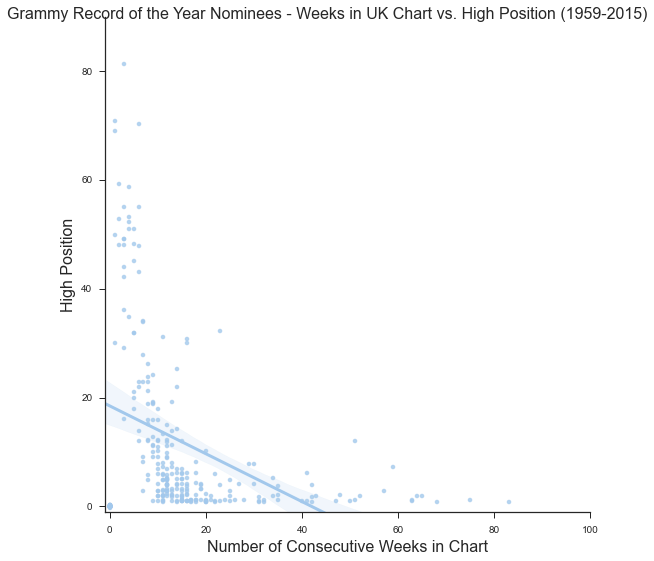

```python
chartchart = sns.lmplot("wks_in_chart", "high_pos", data=everything,
              color=newcolours[3], y_jitter=.25, size=8)
v=(-1, 100, -1, 90)
plt.axis(v)
chartchart.set_axis_labels("Number of Consecutive Weeks in Chart", "High Position")
chartchart.fig.suptitle('Grammy Record of the Year Nominees - Weeks in UK Chart vs. High Position (1959-2015)')
```

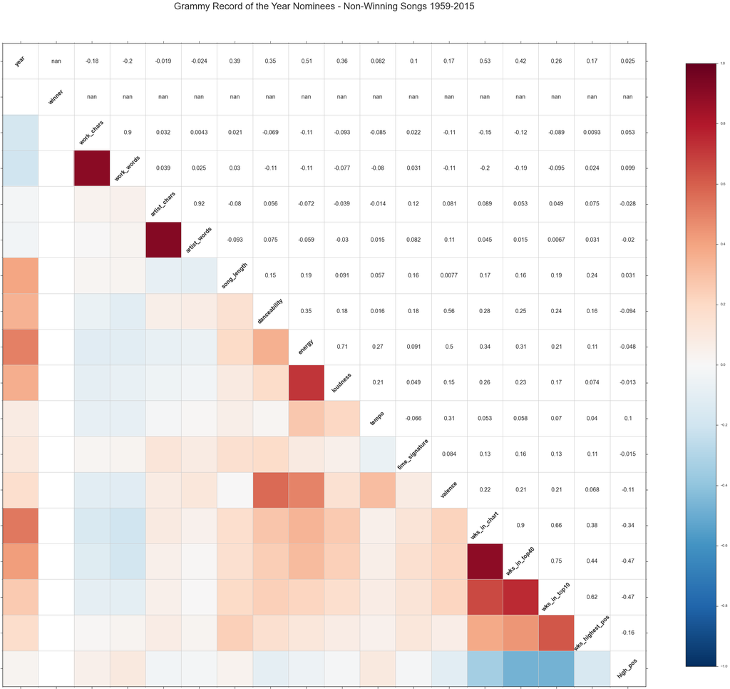

```python
everythinglose = everything[(everything['winner']==0)]
sns.corrplot(everythinglose, cmap='RdBu_r',)
plt.title('Grammy Record of the Year Nominees - Non-Winning Songs 1959-2015')
sns.set_context(rc={"figure.figsize": (40, 40)})
```